# Summary Stats on the New Data Dump

2017-06-02

Let’s do some quick summary stats on the new data dump.

```r
library(readr)
library(dplyr)
library(ggplot2)
library(ggTimeSeries)
library(lubridate)
library(geosphere)
raw_locations <- read_rds('../data/raw/Michigan_DB_user_location_05_31_17.rds')
cleaned_locations <- read_rds('../data/processed/Michigan_DB_user_location_05_31_17_cleaned.rds')
std_locations <- read_rds('../data/processed/std_locations.rds')
twin_distances <- read_rds('../data/processed/twin_distances.rds')
id_mapping <- read_csv('../data/processed/id_mapping_long.csv', col_types = 'ccc')
cleaned_twin_locations <- inner_join(cleaned_locations, id_mapping, by = c("user_id" = "alternate_id"))
user_data <- read_rds('../data/raw/Michigan_DB_users_05_31_17.rds')
comma <- function(x) format(x, digits = 2, big.mark = ",")
twin_app_type <- left_join
```

# Location

In the raw but de-duplicated data, we have 14,454,058 points in the current data dump. After filtering out observations with missing fields, `sample_time` values outside of the appropriate ranges, points with an accuracy greater than or equal to 500 meters, and points that don’t correspond to a twin, we have 9,392,250 points on 618 individuals. Let’s visualize the distribution of the number of points per twin.

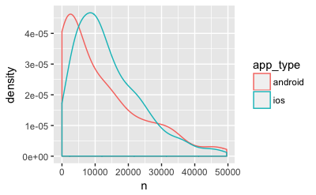

```r
cleaned_twin_locations %>% group_by(user_id) %>% summarize(n = n()) %>% filter(n < 50000) %>% left_join(user_data, by = c("user_id" = "alternate_id")) %>% ggplot(aes(x = n, color = app_type)) + geom_density()
```

This is the opposite of what was expected - since Android records every five minutes and iOS only when the phone moves. This may be because location tracking was deployed to the Android app after the iOS app - meaning that Android users will have fewer points. We can test this by looking at the mean density of location points for iOS vs. Android. We’ll need the length of time between first and last locations for each twin, converting from seconds to days.

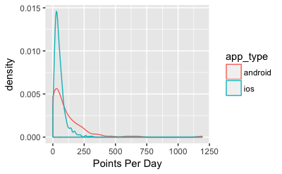

```r
first_last_locs <- cleaned_twin_locations %>% group_by(user_id) %>% summarize(first_point = min(sample_time), last_point = max(sample_time)) %>% mutate(duration_days = as.numeric(last_point - first_point)/60/60/24)
cleaned_twin_locations %>% group_by(user_id) %>% summarize(n = n()) %>% left_join(user_data, by = c("user_id" = "alternate_id")) %>% left_join(first_last_locs) %>% mutate(loc_density = n / duration_days) %>% ggplot(aes(x = loc_density, color = app_type)) + geom_density() + xlab('Points Per Day')
```

Clearly, we are getting far fewer points from most Android devices than we expect. Let’s take a look at the distibution of the time between points.

```r
results <- tibble()
for (twin in unique(cleaned_twin_locations$user_id)) {
  results2 <- cleaned_twin_locations %>% filter(user_id == twin) %>% arrange(sample_time) %>% left_join(user_data, by = c('user_id' = 'alternate_id')) %>% transmute(point_interval = lead(sample_time) - sample_time, app_type = app_type)
  results <- bind_rows(results, results2)
}
```

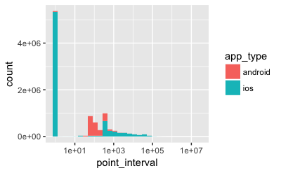

```r
results %>% mutate(point_interval = point_interval + 1) %>% ggplot(aes(x = point_interval, fill = app_type)) + geom_histogram() + scale_x_log10()
```

So, most Android points are falling where we expect - around five minutes, with a long tail where the phone stopped reporting for whatever reason. We also have a very large number of iOS points where `sample_time` was the same for consecutive points. This may have something to do with the algorithm used by iOS to trigger the reporting of a point. Let’s try looking at physical distance between consecutive points.

```r
results <- tibble()
for (twin in unique(cleaned_twin_locations$user_id)) {
  results2 <- cleaned_twin_locations %>% filter(user_id == twin) %>% arrange(sample_time) %>% left_join(user_data, by = c('user_id' = 'alternate_id')) %>% transmute(point_interval = distHaversine(cbind(lead(.$longitude), lead(.$latitude)), cbind(.$longitude, .$latitude)), app_type = app_type)
  results <- bind_rows(results, results2)
}
```

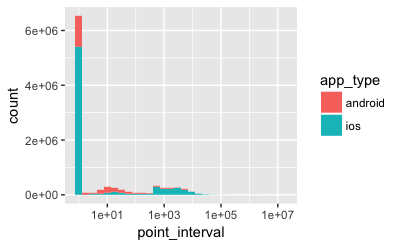

```r
results %>% mutate(point_interval = point_interval + 1) %>% ggplot(aes(x = point_interval, fill = app_type)) + geom_histogram() + scale_x_log10()
```

After doing a little investigating, it became clear that iOS has a lot of duplicates, not across all columns but across `user_id`, `sample_time`, `latitude`, and `longitude`. I have now modified `src/location/clean_location_data.R` to eliminate this issue.

# Parental Monitoring Survey